# HW5

Yongye Tan

2022-11-20

# General Social Survey

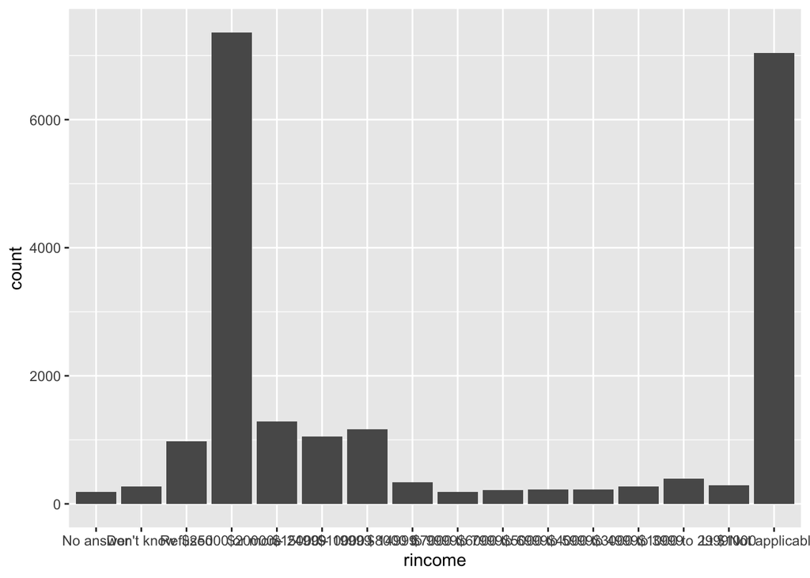

```r
gss_cat %>%
  ggplot(aes(x = rincome)) +
  geom_bar()
```

## a

The x axis label makes the default bar chart hard to understand. The label for some of the incomes are on top of those of other incomes, or the incomes are too long, which occupies the entire section.

## b

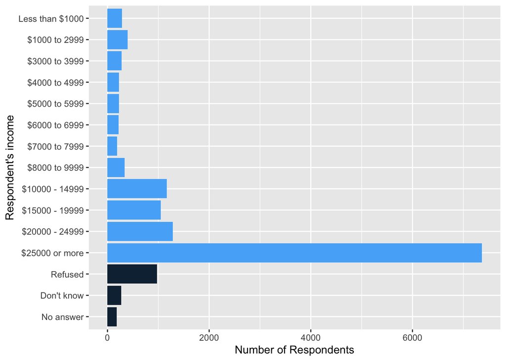

```r
# 1. remove the rows with value "not applicable"
applicable_gss_cat <- gss_cat %>% filter(rincome != 'Not applicable')

# 2. rename “Lt $1000” to “Less than $1000”
# a warning will occur if we try to attempt to add a value to a factor variable in R that does not already exist, so we have to convert the factor variable to a character variable

applicable_gss_cat$rincome <- as.character(applicable_gss_cat$rincome)
# alter the data
applicable_gss_cat$rincome[applicable_gss_cat$rincome == "Lt $1000"] <- "Less than $1000"
# convert the variable back to factor
applicable_gss_cat$rincome <- as.factor(applicable_gss_cat$rincome)

# 3. use color to distinguish non-response categories (“Refused”, “Don’t know”, and “No answer”) from income levels (“Lt $1000”, …)

applicable_gss_cat <- applicable_gss_cat %>% mutate(indicator = case_when(applicable_gss_cat$rincome %in% c("Refused", "Don't know", "No answer") ~ 0,
                                                    !(applicable_gss_cat$rincome %in% c("Refused", "Don't know", "No answer")) ~1
                                                                          )
                                                    )

# rearrange the level of the rincome
applicable_gss_cat$rincome <- factor(applicable_gss_cat$rincome, levels=c( "Less than $1000", "$1000 to 2999", "$3000 to 3999",
                                                                           "$4000 to 4999",  "$5000 to 5999", "$6000 to 6999",
                                                                           "$7000 to 7999",  "$8000 to 9999", "$10000 - 14999", "$15000 - 19999",
                                                                           "$20000 - 24999", "$25000 or more", "Refused", "Don't know", "No answer"))

  ggplot(applicable_gss_cat, aes(y = fct_rev(rincome))) +
  geom_bar(aes(fill = indicator)) +
  # 4. add meaningful y- and x-axis titles
  labs(
    x = "Number of Respondents",
    y = "Respondent's income"
  ) +
  theme(legend.position = "none")
```

# who data

```r
names(who) <- str_replace(names(who), "newrel", "new_rel")
who2 <- who %>%
  pivot_longer(5:60, names_to="codes", values_to="case" ) %>%
  select(-iso2, -iso3) %>%
  separate(codes, c("new", "type", "sexage"), sep = "_") %>%
  select(-new) %>%
  separate(sexage, into = c("sex", "age"), sep = 1,convert=TRUE)

who
```

```
## # A tibble: 7,240 × 60
##    country     iso2  iso3   year new_s…¹ new_s…² new_s…³ new_s…⁴ new_s…⁵ new_s…⁶
##    <chr>       <chr> <chr> <int>   <int>   <int>   <int>   <int>   <int>   <int>
##  1 Afghanistan AF    AFG    1980      NA      NA      NA      NA      NA      NA
##  2 Afghanistan AF    AFG    1981      NA      NA      NA      NA      NA      NA
##  3 Afghanistan AF    AFG    1982      NA      NA      NA      NA      NA      NA
##  4 Afghanistan AF    AFG    1983      NA      NA      NA      NA      NA      NA
##  5 Afghanistan AF    AFG    1984      NA      NA      NA      NA      NA      NA
##  6 Afghanistan AF    AFG    1985      NA      NA      NA      NA      NA      NA
##  7 Afghanistan AF    AFG    1986      NA      NA      NA      NA      NA      NA
##  8 Afghanistan AF    AFG    1987      NA      NA      NA      NA      NA      NA
##  9 Afghanistan AF    AFG    1988      NA      NA      NA      NA      NA      NA
## 10 Afghanistan AF    AFG    1989      NA      NA      NA      NA      NA      NA
## # … with 7,230 more rows, 50 more variables: new_sp_m65 <int>,
## #   new_sp_f014 <int>, new_sp_f1524 <int>, new_sp_f2534 <int>,
## #   new_sp_f3544 <int>, new_sp_f4554 <int>, new_sp_f5564 <int>,
## #   new_sp_f65 <int>, new_sn_m014 <int>, new_sn_m1524 <int>,
## #   new_sn_m2534 <int>, new_sn_m3544 <int>, new_sn_m4554 <int>,
## #   new_sn_m5564 <int>, new_sn_m65 <int>, new_sn_f014 <int>,
## #   new_sn_f1524 <int>, new_sn_f2534 <int>, new_sn_f3544 <int>, …
```

```r
who2
```

```
## # A tibble: 405,440 × 6
##    country      year type  sex     age  case
##    <chr>       <int> <chr> <chr> <int> <int>
##  1 Afghanistan  1980 sp    m        14    NA
##  2 Afghanistan  1980 sp    m      1524    NA
##  3 Afghanistan  1980 sp    m      2534    NA
##  4 Afghanistan  1980 sp    m      3544    NA
##  5 Afghanistan  1980 sp    m      4554    NA
##  6 Afghanistan  1980 sp    m      5564    NA
##  7 Afghanistan  1980 sp    m        65    NA
##  8 Afghanistan  1980 sp    f        14    NA
##  9 Afghanistan  1980 sp    f      1524    NA
## 10 Afghanistan  1980 sp    f      2534    NA
## # … with 405,430 more rows
```

## a

```r
# how many zero value in the "case" column
sum(who2$case==0,na.rm=TRUE)
```

```
## [1] 11080
```

```r
print("I check the number of zeros in the case variable is 11080, meaning there are 11080 missing values that WHO does not have data")
```

```
## [1] "I check the number of zeros in the case variable is 11080, meaning there are 11080 missing values that WHO does not have data"
```

## b

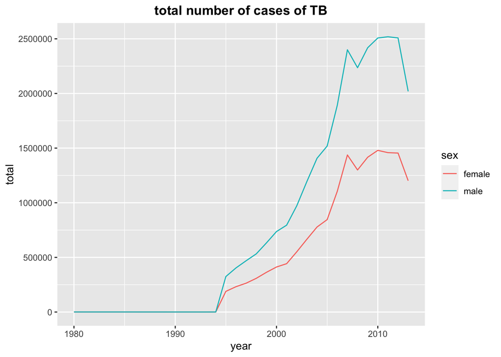

```r
sorted_by_year_year_who2 <- who2 %>% group_by(year, sex) %>%
  # sum up the case, and remove the na values
  summarise(total = sum(case, na.rm = TRUE))

sorted_by_year_year_who2 <- sorted_by_year_year_who2 %>% mutate(sex =
  case_when(sex == 'f' ~ "female", sex == 'm' ~ "male")
)

ggplot(data = sorted_by_year_year_who2,
       mapping = aes(x = year, y = total, color = sex)) +
geom_line() +
scale_fill_discrete(name = "sex",
                    labels = c("female", "male")) +
labs(title = "total number of cases of TB",
     x = "year",
     y = "total") +
  theme(plot.title = element_text(hjust = 0.5, face = "bold"))
```

I found there is a tremendous amount of increase in terms of the total number of cases of TB since 1995 for both genders. Since then, the cases grew exponentially and it had been slowly decreasing since 2010. What is going on in 1995???

## c

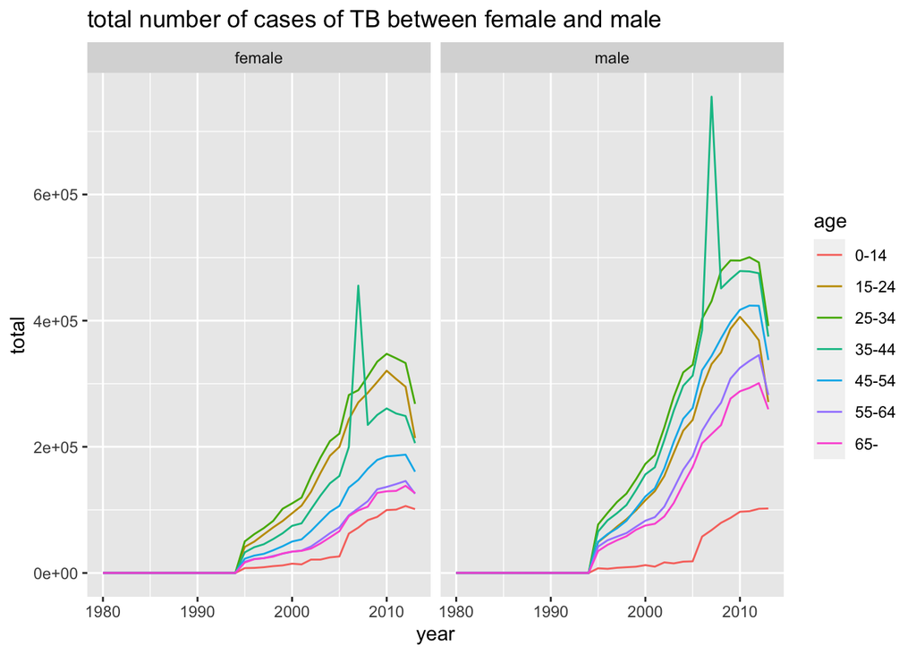

```r
sorted_by_age_group <- who2 %>% group_by(year, age, sex) %>%
  summarise(total = sum(case, na.rm = TRUE))

sorted_by_age_group <- sorted_by_age_group %>% mutate(sex =
  case_when(sex == 'f' ~ "female", sex == 'm' ~ "male"))

sorted_by_age_group <- sorted_by_age_group %>% mutate(age = case_when(
  age == 14 ~ "0-14", age == 65 ~ "65-", age == 1524 ~ "15-24",age == 2534 ~ "25-34",
  age == 3544 ~ "35-44", age == 4554 ~ "45-54", age == 5564 ~ "55-64"))


ggplot(data = sorted_by_age_group,
       # group and color are important to categorize and map color to each age group
  mapping = aes(x = year, y = total, group = age, color = age)) +
  geom_line() +
  facet_grid(~sex) + labs(title = "total number of cases of TB between female and male")
```

## d

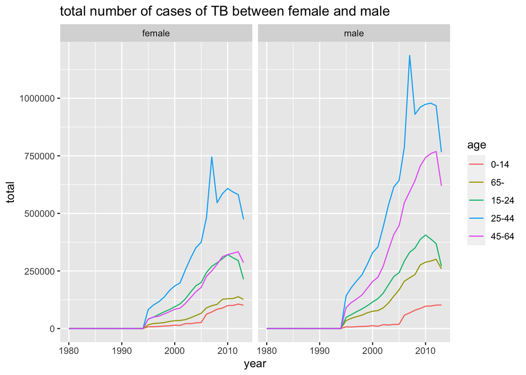

```r
who2 %>%
  filter(!is.na(case)) %>%
  mutate(sex = fct_recode(sex, "female" = "f", "male" = "m")) %>%
  # gives it a level and make it a str
  mutate(age = factor(age)) %>%
  mutate(age = fct_recode(age, "0-14" = "14", "65-" = "65",
                          "15-24" = "1524", "25-34" = "2534",
                          "35-44" = "3544", "45-54" = "4554",
                          "55-64" = "5564")) %>%
  mutate(age = fct_collapse(age, "25-44" = c("25-34", "35-44") ,"45-64" = c("45-54", "55-64"))) %>%
  group_by(year, sex, age) %>%
  summarise(case = sum(case)) %>%
  ggplot(mapping = aes(year, case, color = age)) +
  geom_line() +
  facet_wrap(~sex) +
  labs(x = "year",
      y = "total",
      title = "total number of cases of TB between female and male")
```

I found the number of people from age group 45-64 increases exponetially as year goes on. Also, man has more cases than female, meaning male is more likely to get TB.

# More and more on flights

## a

```r
a<- airports %>%
  semi_join(flights, c("faa" = "dest")) %>%
  ggplot(aes(lon, lat))+
  geom_point()
```

The above code uses the airports and flights dataset. It extracts cases from the airports dataset when the row of “faa” in airports has a match with the row of “dest” in flights dataset. After that, it visualizes a scatter plot graph of their geographic coordinates where x-axis is the longitude, and y-axis is the latitude. In other words, it is a scatter plot contains geographic coordinates of airports where NYC flights fly to as destination.

## b

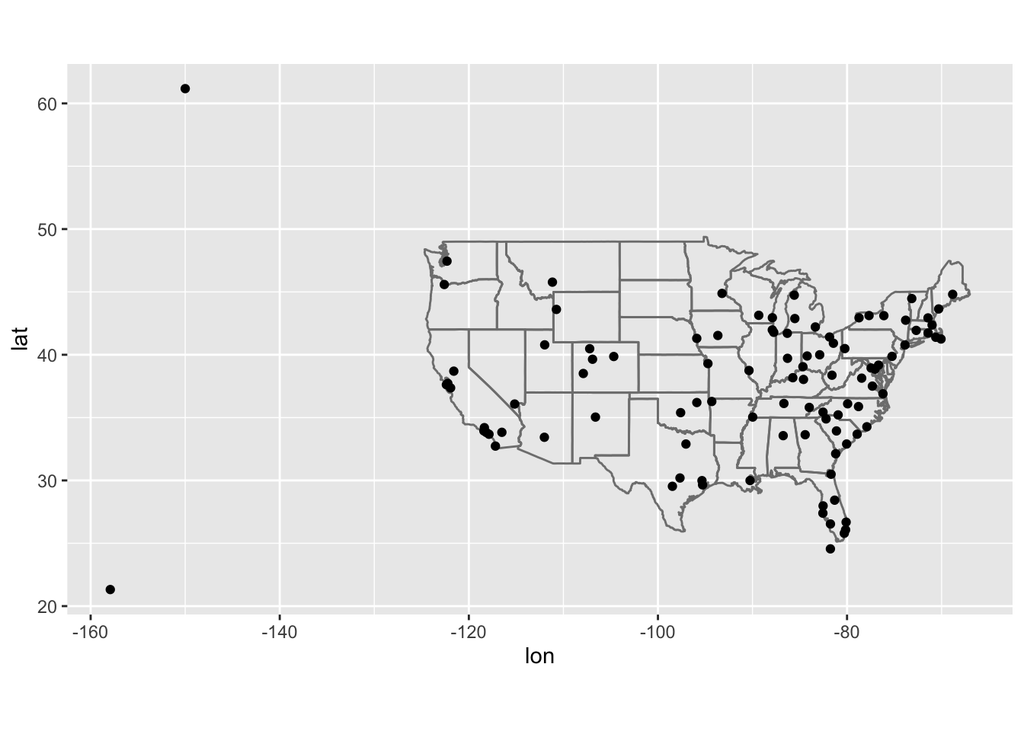

```r
airports %>%
  semi_join(flights, c("faa" = "dest")) %>%
  ggplot(aes(lon, lat)) +
  borders("state") +
  geom_point() +
  coord_quickmap()
```

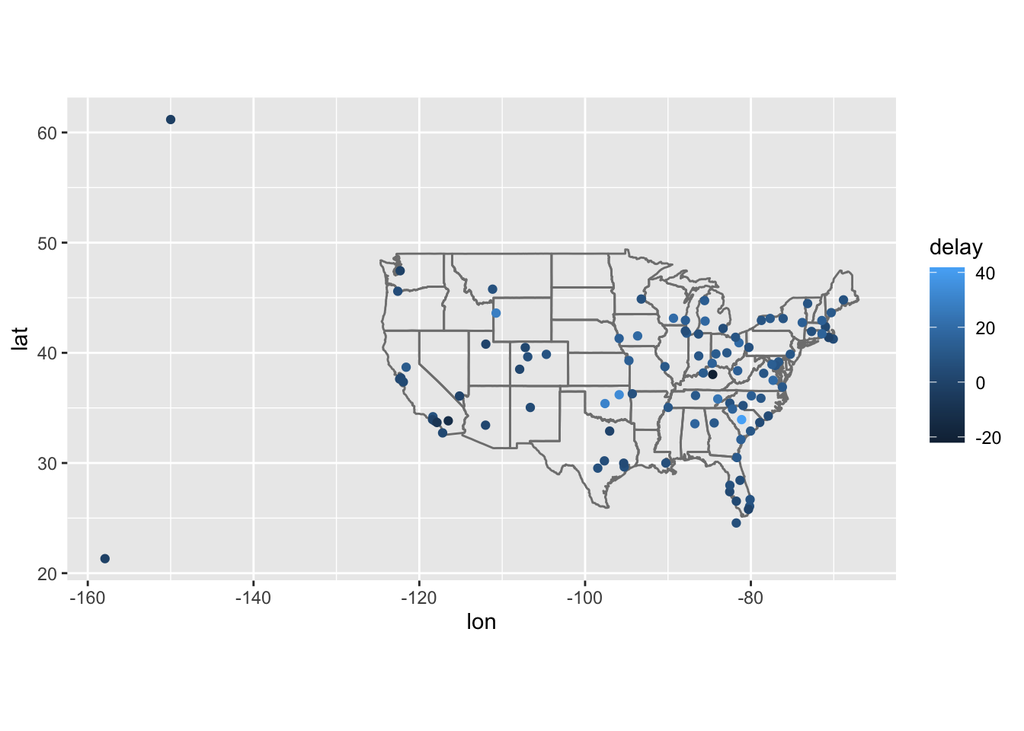

```r
# 1. compute the average arrival delay by destinations from the flights data
  # Since semi_join finds all the airport, we can group by the dest to find all the airport
  flights %>% group_by(dest) %>%
    # remove all the NA values
  summarise(delay = mean(arr_delay, na.rm = TRUE)) %>%
  # 2. join on the airports data to get the longitude and latitude of each destination
  inner_join(airports, by = c(dest = "faa")) %>%
  # 3. plot each destination with tje average arrival data mapping to the size or color aesthetic
  ggplot(aes(lon, lat, color = delay)) +
  # 4. add the borders of the states and change the coordinate using coord_quickmap()
  borders("state") +
  geom_point() +
  coord_quickmap()
```

## c

We need to first get the longitude and latitude of the origin and destination of each flight.

```r
# inner join prevents missing value from both data set
flights %>%
  # 1. # Join flights on airports by origin to get the longitude and latitude of the origin
  # retains origin from both data set
  inner_join(airports, by = c("origin" = "faa")) %>%
  # 2. Then join flights on airports by destination to get the longitude and latitude of the origin
  # retains destination from both data set
  inner_join(airports, by = c("dest" = "faa"))
```

```
## # A tibble: 329,174 × 33
##     year month   day dep_time sched_de…¹ dep_d…² arr_t…³ sched…⁴ arr_d…⁵ carrier
##    <int> <int> <int>    <int>      <int>   <dbl>   <int>   <int>   <dbl> <chr>
##  1  2013     1     1      517        515       2     830     819      11 UA
##  2  2013     1     1      533        529       4     850     830      20 UA
##  3  2013     1     1      542        540       2     923     850      33 AA
##  4  2013     1     1      554        600      -6     812     837     -25 DL
##  5  2013     1     1      554        558      -4     740     728      12 UA
##  6  2013     1     1      555        600      -5     913     854      19 B6
##  7  2013     1     1      557        600      -3     709     723     -14 EV
##  8  2013     1     1      557        600      -3     838     846      -8 B6
##  9  2013     1     1      558        600      -2     753     745       8 AA
## 10  2013     1     1      558        600      -2     849     851      -2 B6
## # … with 329,164 more rows, 23 more variables: flight <int>, tailnum <chr>,
## #   origin <chr>, dest <chr>, air_time <dbl>, distance <dbl>, hour <dbl>,
## #   minute <dbl>, time_hour <dttm>, name.x <chr>, lat.x <dbl>, lon.x <dbl>,
## #   alt.x <dbl>, tz.x <dbl>, dst.x <chr>, tzone.x <chr>, name.y <chr>,
## #   lat.y <dbl>, lon.y <dbl>, alt.y <dbl>, tz.y <dbl>, dst.y <chr>,
## #   tzone.y <chr>, and abbreviated variable names ¹sched_dep_time, ²dep_delay,
## #   ³arr_time, ⁴sched_arr_time, ⁵arr_delay
```

## d

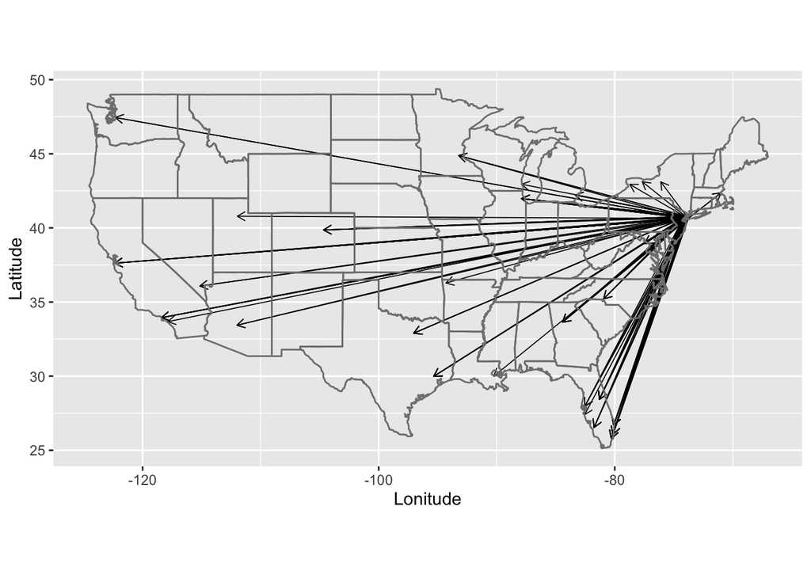

```r
flights %>%
  inner_join(airports, by = c("origin" = "faa")) %>%
  inner_join(airports, by = c("dest" = "faa")) %>%
  # 1. use slice(1:100) to extract the first 100 rows from the data obtained in (c)
  slice(1:100) %>%
  # 2. use geom_segment to draw the route for each flight. Check arrow argument to adjust the size of the arrow
  ggplot(mapping = aes(x = lon.x, y = lat.x, xend = lon.y, yend = lat.y)) +
  geom_segment(size = 0.3, arrow = arrow(length = unit(0.2, "cm"))) +
  # 3. add the borders of the states and change the coordinate using coord_quickmap()
  borders("state") +
  coord_quickmap() +
  labs(x = "Lonitude", y = "Latitude")
```

## e Let’s explore the relationship between the age of a plane (each plane is represented by tailnum) and its delay. The year variable in the planes data shows the year manufactured (so 2013-year is the age).

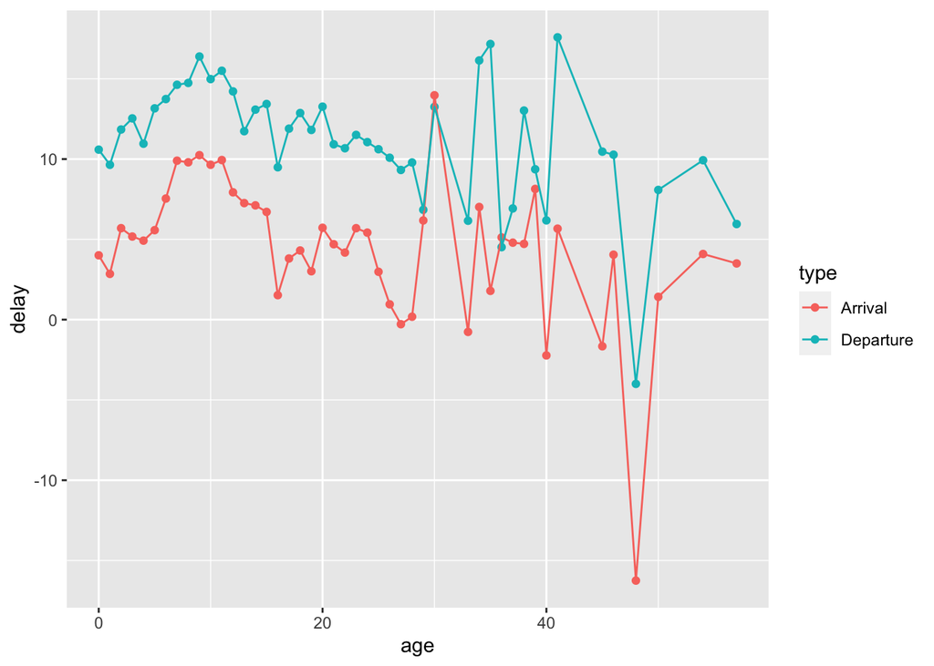

```r
# 1.join flights on planes (note the flights also has a variable year)
f <- flights %>%
  inner_join(planes,by = "tailnum") %>%
#2.calculate the age of the plane
  # year.x is the Year manufactured from plane data
  # year.y is the year of departure for the flight
  mutate(age = year.x - year.y) %>%
  # empty NA age
  filter(!is.na(age)) %>%
  # Since there are more flights that has the same age
  group_by(age) %>%
  #3. calculate the average departure delay and arrival delay by age
 summarise(avg_dep_delay = mean(dep_delay, na.rm = TRUE),
           avg_arr_delay = mean(arr_delay, na.rm = TRUE)) %>%
  # 4 pivot longer the average arr_delay and dep_delay columns into a key:value column pair names type and delay
  pivot_longer(2:3, names_to = "type", values_to = "delay_time" )

# 5. recode the levels of type column to be “Departure” and “Arrival”
f$type <- recode(f$type, avg_dep_delay = "Departure", avg_arr_delay = "Arrival" )

# 6. create the plot

ggplot(data = f, mapping = aes(x = age , y = delay_time, color = type)) +
  geom_point() +
  geom_line() +
  labs( x = "age",
        y = "delay")
```

When age >0 and age < 10, the delay increases rapidly. When the age > 10 and age < 20, the delay decreases at a big rate, slowing leveling it down around 20. This means the plane is new and starts to adjust the function.